# Política de Garantia de Preços Mínimos - PGPM

28/10/2021

## Política de Garantia de Preços Mínimos - PGPM

- **Origem:** década de 40 (comissão -> companhia)
- Mecanismo específico de política de rendas para agropecuária

[figure not shown]

Segundo Bacha, *a política de rendas constitui-se em uma série de regulamentações que restringem a produção e a comercialização de produtos, bem como o uso dos fatores de produção, determina valores mínimos ou máximos para pagamento pelo uso desses fatores ou produtos elaborados em uma economia.*

## Política de Garantia de Preços Mínimos - PGPM

A PGPM é uma política de apoio aos produtores rurais em que o Governo Federal define um preço mínimo de referência para os produtos agrícolas, visando a execução de medidas que garantam uma rentabilidade mínima da produção, não caracterizando a imposição de preço ao mercado.

- Quando intervir no mercado?
  - **Preço de Mercado < Preço Mínimo**

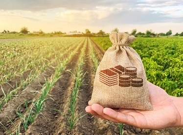

## Política de Garantia de Preços Mínimos - PGPM

### Objetivos

- Evitar a grande oscilação de preços dos principais produtos agrícolas.
- Diminuir oscilações na renda dos produtores rurais, assegurando-lhes uma remuneração mínima.
- Balizar a oferta de alimentos, incentivando a produção.
- Assegurar o abastecimento interno de alimentos.

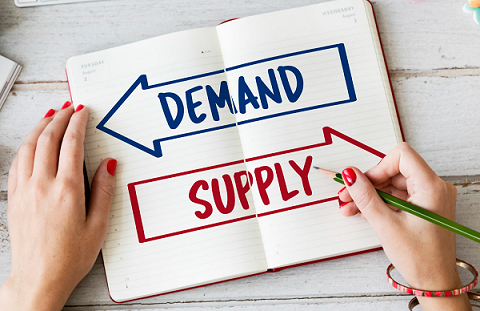

## Política de Garantia de Preços Mínimos para os Produtos da Socio biodiversidade (PGPM-Bio)

- Garante um preço mínimo para 17 produtos extrativistas que ajudam na conservação dos biomas brasileiros:
  - açaí, andiroba, babaçu, baru, borracha extrativa, buriti, cacau extrativo, castanha-do-brasil, juçara, macaúba, mangaba, murumuru, pequi, piaçava, pinhão, pirarucu de manejo e umbu.
- objetiva fomentar a proteção ao meio ambiente, contribuir com a redução do desmatamento, como forma de minimizar os efeitos das mudanças climáticas, garantido, inclusive, renda às populações que possuem formas próprias de organização social, que ocupam e usam territórios e recursos naturais como condição para sua reprodução cultural, social, religiosa, ancestral e econômica, utilizando conhecimentos, inovações e práticas gerados e transmitidos pela tradição.
- **Subvenção Direta a Produtos Extrativistas (SDPE)** que consiste no pagamento de um bônus, quando os extrativistas comprovam a venda de produto extrativo por preço inferior ao mínimo fixado pelo Governo Federal.

## Dinâmica da PGPM

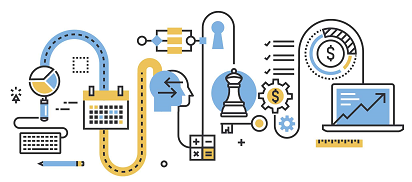

1. Atualização do preço mínimo em cada safra: análise de proposta e aprovação pelo Conselho Monetário Nacional.
2. Publicação do preço mínimo pelo MAPA.
3. Normatização para operacionalização das ações de intervenção (Manual de Operações Conab - MOC).
4. Acompanhamento de mercado, escolha e execução dos Instrumentos de Política Agrícola.

## Preço Mínimo – Base Legal

**Lei nº 8.171, de 17 de janeiro de 1991:** dispõe sobre a política agrícola.

- "Art. 33.
  - §2° A garantia de preços mínimos far-se-á através de financiamento da comercialização e da aquisição dos produtos agrícolas amparados.
  - §3° Os alimentos considerados básicos terão tratamento privilegiado para efeito de preço mínimo.” (Leite, arroz, feijão…)

**Lei nº 8.427**, de 27 de maio 1992: dispõe sobre a concessão de subvenção econômica para equalização de preços.

## Preço Mínimo – Base Legal

**Decreto – Lei nº 79, de 19 de dezembro de 1966:** institui normas para a fixação do PM e execução das operações de financiamento e aquisições de produtos agropecuários.

- “Art.1º A União garantirá os preços dos produtos das atividades agrícola, pecuária ou extrativa, que forem fixados de acordo com este Decreto-lei.”
- “Art.5º Os preços mínimos básicos serão definidos pelo Conselho Monetário Nacional-CMN, levando em conta os diversos **fatores que influem nas cotações dos mercados, interno e externo, e os custos de produção**, com base em proposta encaminhada ao Ministério da Fazenda pelo Ministério da Agricultura, Pecuária e Abastecimento-MAPA.”

## Dados de Produção Agrícola (IBGE)

### 2005 a 2012

(Em 1000 toneladas)

|  | UF | PRODUTO | 2005 | 2006 | 2007 | 2008 | 2009 | 2010 | 2011 | 2012 |
| --- | --- | --- | --- | --- | --- | --- | --- | --- | --- | --- |
| 1 | Acre | Abacate | 0.383 | 0.39 | 0.342 | 0.343 | 0.355 | 0.684 | 0.936 | 0.841 |
| 2 | Acre | Abacaxi* | 2.807 | 2.71 | 2.664 | 3.582 | 3.802 | 6.55 | 6.778 | 7.712 |
| 3 | Acre | Algodão (em caroço) | 0.126 | 0.028 |  |  |  |  |  |  |
| 4 | Acre | Amendoim (em casca) | 0.036 | 0.093 | 0.097 | 0.161 | 0.216 | 0.203 | 0.339 | 0.566 |
| 5 | Acre | Arroz (em casca) | 31.561 | 32.49 | 28.099 | 28.569 | 21.14 | 25.826 | 23.746 | 18.358 |
| 6 | Acre | Banana (cacho) | 55.479 | 75.589 | 90.786 | 94.964 | 50.109 | 65.623 | 69.73 | 64.112 |
| 7 | Acre | Batata-doce | 0.098 | 0.088 | 0.098 | 0.19 | 0.167 | 0.306 | 0.426 | 0.532 |
| 8 | Acre | Borracha (látex coagulado) | 0.634 | 0.559 | 0.553 | 0.427 | 0.394 | 0.636 | 0.794 | 0.85 |
| 9 | Acre | Café (em grão) | 2.185 | 1.131 | 1.37 | 1.579 | 0.9 | 1.029 | 1.374 | 2.906 |
| 10 | Acre | Cana-de-açúcar | 25.69 | 35.248 | 37.138 | 52.609 | 38.65 | 107.251 | 179.044 | 199.37 |

[output cut: 898 more lines]

## Dados de Produção Agrícola (IBGE)

### 2013 a 2020

(Em 1000 toneladas)

|  | UF | PRODUTO | 2013 | 2014 | 2015 | 2016 | 2017 | 2018 | 2019 | 2020 |
| --- | --- | --- | --- | --- | --- | --- | --- | --- | --- | --- |
| 1 | Acre | Abacate | 0.758 | 0.697 | 0.704 | 0.729 | 0.722 | 0.545 | 0.548 | 0.537 |
| 2 | Acre | Abacaxi* | 7.05 | 7.519 | 7.7 | 8.441 | 8.042 | 6.379 | 6.155 | 6.182 |
| 3 | Acre | Amendoim (em casca) | 0.433 | 0.476 | 0.443 | 0.398 | 0.277 | 0.211 | 0.122 | 0.12 |
| 4 | Acre | Arroz (em casca) | 15.407 | 7.49 | 7.144 | 6.375 | 6.259 | 6.201 | 4.54 | 4.626 |
| 5 | Acre | Banana (cacho) | 77.742 | 100.969 | 106.268 | 113.545 | 102.949 | 90.68 | 88.169 | 88.768 |
| 6 | Acre | Batata-doce | 0.66 | 0.773 | 0.786 | 0.742 | 0.702 | 0.63 | 0.596 | 0.591 |
| 7 | Acre | Borracha (látex coagulado) | 0.816 | 0.641 | 0.72 | 0.266 | 0.298 | 0.282 | 0.238 | 0.196 |
| 8 | Acre | Café (em grão) | 2.822 | 4 | 4.458 | 4.338 | 5.258 | 3.938 | 4.114 | 4.282 |
| 9 | Acre | Cana-de-açúcar | 152.345 | 188.976 | 197.376 | 117.244 | 20.229 | 11.989 | 12.119 | 11.822 |
| 10 | Acre | Coco-da-baía* | 1.531 | 1.39 | 1.427 | 1.541 | 1.692 | 1.346 | 1.31 | 1.376 |

[output cut: 921 more lines]

## Execução e Instrumentos

### **CONAB**

- **AGF** - Aquisição do Governo Federal
- **PEP** - Prêmio para o Escoamento de Produto
- **PEPRO** - Prêmio Equalizador Pago ao Produtor
- **COV** - Contrato de Opção de Venda Público
- **VEP** - Venda de Produtos Agropecuários dos Estoques Públicos

### **INSTITUIÇÕES FINANCEIRAS**

- **FEPM** - Financiamento para Estocagem de Produtos Agropecuários integrantes da Política de Garantia de Preços Mínimos
- **FEE** - Financiamento Especial para Estocagem de Produtos Agropecuários
- **FGPP** - Financiamento para Garantia de Preços ao Produtor

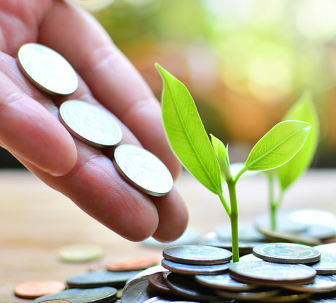

## Aquisição do Governo Federal - AGF

[figure not shown]

**O que é:** aquisição direta de produtos da pauta da PGPM.

**Execução:** operada quando o preço de mercado estiver abaixo do mínimo fixado.

**Beneficiários:** produtores rurais e/ou suas cooperativas.

**Limites:** da produção, das normas e de recursos.

**Como deve estar o produto:** limpo, seco, nos padrões e depositado em armazém credenciado Condicionada ao repasse pelo Tesouro Nacional dos recursos para a operacionalização das aquisições.

## Dados AGF (MAPA/CONAB)

(Em 1000 toneladas)

|  | PRODUTO | UF | 2005 | 2006 | 2007 | 2008 | 2009 | 2010 |
| --- | --- | --- | --- | --- | --- | --- | --- | --- |
| 1 | Algodão (em caroço) | Mato Grosso do Sul | 0.7 | 0.3 |  |  |  |  |
| 2 | Algodão (em caroço) | Paraná | 0.8 | 0.1 |  |  |  |  |
| 3 | Algodão (em caroço) | São Paulo | 3.1 |  |  |  |  |  |
| 4 | Arroz (em casca) | Mato Grosso | 203 | 5.3 |  |  |  |  |
| 5 | Arroz (em casca) | Pará | 3.2 |  |  |  |  |  |
| 6 | Arroz (em casca) | Rondônia | 21.1 |  |  |  |  |  |
| 7 | Arroz (em casca) | Rio Grande do Sul | 312.7 | 290.4 | 62 |  | 0.3 |  |
| 8 | Arroz (em casca) | Santa Catarina | 22.5 | 12 |  |  |  |  |
| 9 | Arroz (em casca) | Tocantins | 4.2 |  |  |  |  |  |
| 10 | Milho (em grão) | Goiás | 160.2 | 596.9 | 44.4 |  | 289.9 | 137.4 |

[output cut: 30 more lines]

## Dados AGF (MAPA/CONAB)

(Em 1000 toneladas)

|  | PRODUTO | UF | 2011 | 2012 | 2013 | 2014 | 2015 | 2018 |
| --- | --- | --- | --- | --- | --- | --- | --- | --- |
| 1 | Arroz (em casca) | Rio Grande do Sul | 395.1 |  |  |  |  | 20.45 |
| 2 | Arroz (em casca) | Santa Catarina | 1.3 |  |  |  |  |  |
| 3 | Feijão (em grão) | Distrito Federal | 0.1 |  |  | 4.13 |  |  |
| 4 | Feijão (em grão) | Goiás | 0.5 |  |  | 7.87 |  |  |
| 5 | Feijão (em grão) | Mato Grosso do Sul | 0.3 |  |  | 1.36 |  |  |
| 6 | Feijão (em grão) | Paraná | 21 |  |  | 16.87 |  |  |
| 7 | Feijão (em grão) | Rondônia | 2.4 |  |  |  |  |  |
| 8 | Feijão (em grão) | Santa Catarina | 8.9 |  |  | 6.74 |  |  |
| 9 | Feijão (em grão) | São Paulo | 1.2 |  |  | 5.52 |  |  |
| 10 | Milho (em grão) | Goiás | 1.2 |  |  |  |  |  |

[output cut: 18 more lines]

## Participação AGF/Produção

### 2005 a 2010

(% da produção)

|  | NO_REGIAO | PRODUTO | 2005 | 2006 | 2007 | 2008 | 2009 | 2010 |
| --- | --- | --- | --- | --- | --- | --- | --- | --- |
| 1 | REGIAO CENTRO OESTE | Algodão (em caroço) | 0.0303349673769094 | 0.0171944601741913 |  |  |  |  |
| 2 | REGIAO CENTRO OESTE | Arroz (em casca) | 7.0909078842163 | 0.465583701407995 |  |  |  |  |
| 3 | REGIAO CENTRO OESTE | Milho (em grão) | 7.20558192073427 | 20.9661452334908 | 2.02110019731795 | 0.878610623733669 | 5.57687723671012 | 1.0539468442087 |
| 4 | REGIAO CENTRO OESTE | Trigo (em grão) | 1.91543112730887 |  |  | 2.77320493984505 |  |  |
| 5 | REGIAO CENTRO OESTE | Feijão (em grão) |  | 0.128830451396136 | 0.0522099151849928 |  | 2.02350377461281 | 0.556026633675753 |
| 6 | REGIAO CENTRO OESTE | Sorgo (em grão) |  | 1.7486463240811 |  |  | 0.486920594426276 |  |
| 7 | REGIAO CENTRO OESTE | Café (em grão) |  |  |  |  |  | 0.53232546378856 |
| 8 | REGIAO NORDESTE | Sisal ou agave (fibra) |  | 0.161218164450589 | 1.87457465493563 | 3.04582133618151 | 3.8213603328512 | 0.52730849575111 |
| 9 | REGIAO NORDESTE | Milho (em grão) |  |  |  |  | 0.329208092018246 |  |
| 10 | REGIAO NORTE | Arroz (em casca) | 1.92324303313647 |  |  |  |  |  |

[output cut: 10 more lines]

## Participação AGF/Produção

### 2011 a 2020

(% da produção)

|  | NO_REGIAO | PRODUTO | 2011 | 2012 | 2013 | 2014 | 2018 |
| --- | --- | --- | --- | --- | --- | --- | --- |
| 1 | REGIAO CENTRO OESTE | Feijão (em grão) | 0.152843915793192 |  |  | 1.92529120750057 |  |
| 2 | REGIAO CENTRO OESTE | Milho (em grão) | 0.00689657392000802 |  | 1.01486184314914 | 0.0439339836043363 |  |
| 3 | REGIAO NORDESTE | Arroz (em casca) |  | 0.00424094205459506 |  |  |  |
| 4 | REGIAO NORDESTE | Feijão (em grão) |  |  |  | 0.348320502292986 |  |
| 5 | REGIAO NORTE | Feijão (em grão) | 2.00195190310553 |  |  | 0.069301990353163 |  |
| 6 | REGIAO SUDESTE | Feijão (em grão) | 0.146873252055308 |  |  | 1.0646544909294 |  |
| 7 | REGIAO SUDESTE | Trigo (em grão) | 0.124516018096328 |  |  |  |  |
| 8 | REGIAO SUL | Arroz (em casca) | 3.91972552428554 |  |  |  | 0.212375345019066 |
| 9 | REGIAO SUL | Feijão (em grão) | 2.74027340413442 |  |  | 2.23456583507782 |  |
| 10 | REGIAO SUL | Trigo (em grão) | 0.0221440577989434 | 10.7545822193481 |  | 0.260954341340804 |  |

## Participação AGF/Produção

### 2005 a 2020

(% da produção)

|  | NO_REGIAO | 2005 | 2006 | 2007 | 2008 | 2009 | 2010 | 2011 | 2012 | 2013 | 2014 | 2018 |
| --- | --- | --- | --- | --- | --- | --- | --- | --- | --- | --- | --- | --- |
| 1 | REGIAO CENTRO OESTE | 0.917393668932998 | 2.41736402945391 | 0.268463928126503 | 0.121350084323655 | 0.638984449924839 | 0.116885031243246 | 0.00126820887508876 |  | 0.169376426586331 | 0.0131960926446479 |  |
| 2 | REGIAO NORDESTE |  | 0.000418728805714367 | 0.00451741572277311 | 0.00678521805686934 | 0.0255521720729936 | 0.00126857117452263 |  | 3.03704517856778e-05 |  | 0.00229611453159982 |  |
| 3 | REGIAO NORTE | 0.18250259858086 | 0.0919554108846795 |  |  | 0.162504786225874 |  | 0.0124936119901611 |  |  | 0.000216770088398409 |  |
| 4 | REGIAO SUDESTE | 0.00801000742056511 | 0.0133388220252774 |  | 0.0121749154997559 | 0.00568861370421593 | 0.00853955207802679 | 0.000254812016961466 |  |  | 0.00157057430959425 |  |
| 5 | REGIAO SUL | 1.03151347994305 | 0.382097184516491 | 0.0795638885684683 | 0.132424002289769 | 0.124743761257699 | 0.0971090609577547 | 0.325818798455114 | 0.3691497304768 |  | 0.0284459810636786 | 0.0156048350906209 |

## Prêmio para o Escoamento de Produto – PEP

**O que é:** É uma subvenção econômica, para escoamento de produto do local de produção, para o de consumo, concedida àqueles que se disponham a adquirir o produto indicado pelo Governo Federal, diretamente do produtor rural e/ou cooperativa, pelo valor do preço mínimo fixado.

*Esse instrumento é lançado quando o preço de mercado de um determinado produto está abaixo do Preço Mínimo ou do valor de referência.*

**Seleção do beneficiário:** através de leilão público em bolsas de cereais/mercadorias.

**Obrigação:** pagar o preço mínimo e escoar o produto, recebendo o bônus para tal.

**Operação com leite em 2014: R$ 14 milhões - 170 mil toneladas.**

## Dados PEP (MAPA/CONAB)

(Em 1000 toneladas)

|  | PRODUTO | UF | 2005 | 2006 | 2007 | 2008 | 2009 | 2010 |
| --- | --- | --- | --- | --- | --- | --- | --- | --- |
| 1 | Algodão (em caroço) | Bahia | 47.1 |  |  |  |  |  |
| 2 | Algodão (em caroço) | Distrito Federal | 0.5 |  |  |  |  |  |
| 3 | Algodão (em caroço) | Goiás | 40.7 |  |  |  |  |  |
| 4 | Algodão (em caroço) | Maranhão | 2 |  |  |  |  |  |
| 5 | Algodão (em caroço) | Minas Gerais | 13.1 |  |  |  |  |  |
| 6 | Algodão (em caroço) | Mato Grosso do Sul | 17.2 | 0.8 |  |  |  |  |
| 7 | Algodão (em caroço) | Mato Grosso | 61.6 |  |  |  |  |  |
| 8 | Algodão (em caroço) | Paraná | 10 | 1 |  |  |  |  |
| 9 | Algodão (em caroço) | São Paulo | 5.5 |  |  |  |  |  |
| 10 | Milho (em grão) | Bahia | 67.9 |  | 119.6 |  | 117.8 | 423.9 |

[output cut: 45 more lines]

## Dados PEP (MAPA/CONAB)

(Em 1000 toneladas)

|  | PRODUTO | UF | 2011 | 2012 | 2016 | 2017 | 2018 |
| --- | --- | --- | --- | --- | --- | --- | --- |
| 1 | Arroz (em casca) | Rio Grande do Sul | 1417.8 |  |  | 95 | 330.5 |
| 2 | Arroz (em casca) | Mato Grosso do Sul | 5.6 |  |  |  |  |
| 3 | Arroz (em casca) | Santa Catarina | 114.8 |  |  | 15 | 59.68 |
| 4 | Sisal ou agave (fibra) | Bahia | 91 | 6.3 |  |  |  |
| 5 | Sisal ou agave (fibra) | Paraíba | 2.6 | 0.9 |  |  |  |
| 6 | Sisal ou agave (fibra) | Rio Grande do Norte | 0 |  |  |  |  |
| 7 | Trigo (em grão) | Mato Grosso do Sul | 3.5 |  |  |  |  |
| 8 | Trigo (em grão) | Paraná | 362.7 | 341.5 | 21.2 | 27 |  |
| 9 | Trigo (em grão) | Rio Grande do Sul | 413.4 | 1202.6 | 22.6 | 36.8 |  |
| 10 | Trigo (em grão) | Santa Catarina | 56.8 | 49.9 | 4 |  |  |

[output cut: 6 more lines]

## Participação PEP/Produção

### 2005 a 2010

(% da produção)

|  | NO_REGIAO | PRODUTO | 2005 | 2006 | 2007 | 2008 | 2009 | 2010 |
| --- | --- | --- | --- | --- | --- | --- | --- | --- |
| 1 | REGIAO CENTRO OESTE | Algodão (em caroço) | 5.20028012175589 | 0.0458518937978436 |  |  |  |  |
| 2 | REGIAO CENTRO OESTE | Milho (em grão) | 8.78490498036536 | 11.9544939325276 | 7.84405773616959 | 3.49432615742158 | 29.313960910666 | 54.1851974291996 |
| 3 | REGIAO CENTRO OESTE | Trigo (em grão) | 5.17684088461857 |  |  |  | 11.7772710215628 | 12.7415195031423 |
| 4 | REGIAO CENTRO OESTE | Soja (em grão) |  | 16.8714504769901 |  |  |  |  |
| 5 | REGIAO CENTRO OESTE | Feijão (em grão) |  |  | 2.8976502927671 |  | 1.51762783095961 |  |
| 6 | REGIAO NORDESTE | Algodão (em caroço) | 5.48806318314371 |  |  |  |  |  |
| 7 | REGIAO NORDESTE | Milho (em grão) | 2.37960007718359 |  | 3.82344018186276 |  | 2.92953529985857 | 10.238803980163 |
| 8 | REGIAO NORDESTE | Soja (em grão) |  | 15.3809865169822 |  |  |  |  |
| 9 | REGIAO NORDESTE | Sisal ou agave (fibra) |  |  |  |  |  | 23.3232603889914 |
| 10 | REGIAO NORTE | Soja (em grão) |  | 11.9928581499947 |  |  |  |  |

[output cut: 13 more lines]

## Participação PEP/Produção

### 2011 a 2020

(% da produção)

|  | NO_REGIAO | PRODUTO | 2011 | 2012 | 2016 | 2017 | 2018 |
| --- | --- | --- | --- | --- | --- | --- | --- |
| 1 | REGIAO CENTRO OESTE | Arroz (em casca) | 0.552476376702071 |  |  |  |  |
| 2 | REGIAO CENTRO OESTE | Trigo (em grão) | 3.42034027499536 |  |  |  |  |
| 3 | REGIAO CENTRO OESTE | Milho (em grão) |  |  |  | 3.8445966561527 |  |
| 4 | REGIAO NORDESTE | Sisal ou agave (fibra) | 32.9813211556148 | 8.0782694551656 |  |  |  |
| 5 | REGIAO SUDESTE | Trigo (em grão) | 7.70813445358221 |  |  |  |  |
| 6 | REGIAO SUDESTE | Laranja |  | 0.00209780234226624 |  |  |  |
| 7 | REGIAO SUL | Arroz (em casca) | 15.1548217419778 |  |  | 1.0971477450073 | 4.0520592723491 |
| 8 | REGIAO SUL | Trigo (em grão) | 15.3698214506166 | 38.4626521374038 | 0.780968803237197 | 1.74920942862266 |  |
| 9 | REGIAO SUL | Uva |  | 7.87971115807509 |  |  |  |

## Participação PEP/Produção por Região

### 2005 a 2020

(% da produção)

|  | NO_REGIAO | 2005 | 2006 | 2007 | 2008 | 2009 | 2010 | 2011 | 2012 | 2016 | 2017 | 2018 |
| --- | --- | --- | --- | --- | --- | --- | --- | --- | --- | --- | --- | --- |
| 1 | REGIAO CENTRO OESTE | 0.972774077851265 | 6.29921220732034 | 1.05206449055205 | 0.467815664500982 | 3.31660273440155 | 5.92292915232991 | 0.00549557179205131 |  |  | 0.775786284491446 |  |
| 2 | REGIAO NORDESTE | 0.129122744526197 | 0.558374862420108 | 0.117452808792101 |  | 0.135571146923128 | 0.469761664165532 | 0.0836651768961617 | 0.00728890842856267 |  |  |  |
| 3 | REGIAO NORTE |  | 0.960141324685551 |  |  | 0.191939615429051 | 0.247878704215254 |  |  |  |  |  |
| 4 | REGIAO SUDESTE | 0.00547743154494526 | 0.0365034693840265 | 0.0013428149987262 |  | 0.0201010410420784 | 0.0770575461118082 | 0.00234933065283621 | 5.54094077018013e-05 |  |  |  |
| 5 | REGIAO SUL | 1.42908845240077 | 2.79357970681853 | 0.184864259459594 | 0.259211297776534 | 2.34260850553963 | 3.0724142803653 | 1.8028640181183 | 1.3848291437227 | 0.0349198433624402 | 0.124283059975079 | 0.297735675093323 |

## Prêmio Equalizador Pago ao Produtor – PEPRO

**O que é:** subvenção econômica para escoamento de produto do local de produção para o de consumo.

**Lançamento:** quando o preço de mercado estiver abaixo do mínimo.

**Beneficiários:** aqueles que se disponham a adquirir o produto indicado pelo Governo Federal, diretamente do produtor rural e/ou cooperativa.

**Seleção do beneficiário:** através de leilão público em bolsas de cereais/mercadorias.

**Obrigação:** pagar o preço mínimo e escoar o produto, recebendo o bônus para tal.

## Dados PEPRO (MAPA/CONAB)

### 2005 a 2012

(Em 1000 toneladas)

|  | PRODUTO | UF | 2006 | 2007 | 2008 | 2009 | 2010 | 2011 | 2012 |
| --- | --- | --- | --- | --- | --- | --- | --- | --- | --- |
| 1 | Algodão (em caroço) | Bahia | 161.4 | 203.9 | 318.2 | 253.2 |  |  |  |
| 2 | Algodão (em caroço) | Distrito Federal | 1.2 | 1 |  |  |  |  |  |
| 3 | Algodão (em caroço) | Goiás | 32.9 | 53 | 68.6 | 61.9 |  |  |  |
| 4 | Algodão (em caroço) | Maranhão | 3.3 | 4.1 | 11.7 | 10.9 |  |  |  |
| 5 | Algodão (em caroço) | Minas Gerais | 8.8 | 18.7 | 18.5 | 13.9 |  |  |  |
| 6 | Algodão (em caroço) | Mato Grosso do Sul | 15 | 31.6 | 47 | 38 |  |  |  |
| 7 | Algodão (em caroço) | Mato Grosso | 234.8 | 392.8 | 527.8 | 394.9 |  |  |  |
| 8 | Algodão (em caroço) | Piauí | 2 | 8.4 | 14.6 | 8.1 |  |  |  |
| 9 | Algodão (em caroço) | São Paulo | 2.3 | 11.6 | 13.5 | 6.7 |  |  |  |
| 10 | Milho (em grão) | Mato Grosso | 100 | 3068.6 |  | 1337.4 | 234.3 |  |  |

[output cut: 33 more lines]

## Dados PEPRO (MAPA/CONAB)

### 2013 a 2020

(Em 1000 toneladas)

|  | PRODUTO | UF | 2013 | 2014 | 2015 | 2016 | 2017 | 2018 | 2019 |
| --- | --- | --- | --- | --- | --- | --- | --- | --- | --- |
| 1 | Laranja | Minas Gerais | 3.88 | 1.56 |  |  |  |  |  |
| 2 | Laranja | São Paulo | 178 | 723.19 |  |  |  |  |  |
| 3 | Milho (em grão) | Goiás | 228.3 | 325 |  |  | 164.3 |  |  |
| 4 | Milho (em grão) | Mato Grosso do Sul | 278.3 | 30 |  |  | 217.4 |  |  |
| 5 | Milho (em grão) | Mato Grosso | 8355.1 | 5057.98 |  |  | 6914.9 |  |  |
| 6 | Uva | Rio Grande do Sul | 25.4 |  |  |  |  |  |  |
| 7 | Algodão (em caroço) | Bahia |  | 216.67 |  |  |  |  |  |
| 8 | Algodão (em caroço) | Goiás |  | 46.37 |  |  |  |  |  |
| 9 | Algodão (em caroço) | Maranhão |  | 17.4 |  |  |  |  |  |
| 10 | Algodão (em caroço) | Minas Gerais |  | 14.78 |  |  |  |  |  |

[output cut: 25 more lines]

## Participação PEPRO/Produção

(% da produção)

|  | NO_REGIAO | PRODUTO | 2006 | 2007 | 2008 | 2009 | 2010 | 2011 | 2012 |
| --- | --- | --- | --- | --- | --- | --- | --- | --- | --- |
| 1 | REGIAO CENTRO OESTE | Algodão (em caroço) | 16.2716908115097 | 17.7948319850202 | 25.2382710097623 | 27.6817538192484 |  |  |  |
| 2 | REGIAO CENTRO OESTE | Milho (em grão) | 0.989856250105791 | 26.7483330175595 |  | 10.1407657567579 | 1.68524796292763 |  |  |
| 3 | REGIAO CENTRO OESTE | Soja (em grão) | 18.4738446205637 | 13.6961284564491 |  |  |  |  |  |
| 4 | REGIAO CENTRO OESTE | Feijão (em grão) |  | 3.55027423257951 |  | 1.28414662619659 |  |  |  |
| 5 | REGIAO NORDESTE | Algodão (em caroço) | 18.8006599967745 | 18.2351354995281 | 26.9185208800208 | 27.2733739929041 |  |  |  |
| 6 | REGIAO NORDESTE | Soja (em grão) | 12.3993704580097 | 2.08480420746744 |  |  |  |  |  |
| 7 | REGIAO NORDESTE | Milho (em grão) |  | 3.99607042418767 |  | 4.75476497459264 | 14.2700764130226 |  |  |
| 8 | REGIAO NORTE | Soja (em grão) | 9.34714175494963 | 4.54044292449072 |  |  |  |  |  |
| 9 | REGIAO NORTE | Milho (em grão) |  | 1.0466155071039 |  |  |  |  |  |
| 10 | REGIAO NORTE | Algodão (em caroço) |  |  |  | 20.7648382073023 |  |  |  |

[output cut: 9 more lines]

## Participação PEPRO/Produção

(% da produção)

|  | NO_REGIAO | PRODUTO | 2013 | 2014 | 2015 | 2016 | 2017 | 2018 | 2019 |
| --- | --- | --- | --- | --- | --- | --- | --- | --- | --- |
| 1 | REGIAO CENTRO OESTE | Milho (em grão) | 24.7071461413043 | 15.0040236322145 |  |  | 14.5289434230805 |  |  |
| 2 | REGIAO CENTRO OESTE | Algodão (em caroço) |  | 22.8136733638941 |  |  |  |  |  |
| 3 | REGIAO CENTRO OESTE | Borracha (látex coagulado) |  | 4.16058071083964 | 15.7482125204037 |  |  |  |  |
| 4 | REGIAO CENTRO OESTE | Trigo (em grão) |  | 7.58566570755951 |  |  |  |  |  |
| 5 | REGIAO NORDESTE | Algodão (em caroço) |  | 18.9721712509741 |  |  |  |  |  |
| 6 | REGIAO NORDESTE | Borracha (látex coagulado) |  | 0.54472588615229 | 2.54418595686448 |  |  |  |  |
| 7 | REGIAO NORDESTE | Milho (em grão) |  | 5.24503156131638 |  |  |  |  |  |
| 8 | REGIAO NORTE | Algodão (em caroço) |  | 18.7540418193576 |  |  |  |  |  |
| 9 | REGIAO NORTE | Milho (em grão) |  | 2.22774497238464 |  |  |  |  |  |
| 10 | REGIAO NORTE | Borracha (látex coagulado) |  |  | 5.05760044956448 |  |  |  |  |

[output cut: 8 more lines]

## Participação PEPRO/Produção por Região

### 2005 a 2020

(% da produção)

|  | NO_REGIAO | 2006 | 2007 | 2008 | 2009 | 2010 | 2011 | 2012 |
| --- | --- | --- | --- | --- | --- | --- | --- | --- |
| 1 | REGIAO CENTRO OESTE | 5.83705248300053 | 7.5558608158924 | 0.509638670064226 | 1.5011097533651 | 0.183796539725967 |  |  |
| 2 | REGIAO NORDESTE | 0.624638695924407 | 0.41530763242625 | 0.311667682745532 | 0.482502147370793 | 0.576516807621513 |  |  |
| 3 | REGIAO NORTE | 0.748326792027047 | 0.404190027738013 |  | 0.0147174146015885 |  |  |  |
| 4 | REGIAO SUDESTE | 0.0380882799216832 | 0.013852196828965 | 0.00648248412632593 | 0.00397057600831179 |  | 0.00180717742525862 | 0.202336687124411 |
| 5 | REGIAO SUL |  | 0.0159939653550901 | 0.00293417614402987 | 0.00979493517987128 |  | 0.0816261831919129 | 0.034040955626198 |

|  | NO_REGIAO | 2013 | 2014 | 2015 | 2016 | 2017 | 2018 | 2019 |
| --- | --- | --- | --- | --- | --- | --- | --- | --- |
| 1 | REGIAO CENTRO OESTE | 4.12352494362662 | 2.7391718153941 | 0.00296790669476736 |  | 2.93173928082675 |  |  |
| 2 | REGIAO NORDESTE |  | 0.582138314011562 | 0.00136907653350444 |  |  |  |  |
| 3 | REGIAO NORTE |  | 0.182000166219304 | 0.000710662155120098 |  |  |  |  |
| 4 | REGIAO SUDESTE | 0.0321070737793723 | 0.142053273752678 | 0.00463837603275315 |  |  |  |  |
| 5 | REGIAO SUL | 0.0182736828764642 | 0.600414953006545 |  | 0.295795911662176 | 0.367400175799747 | 0.0834267296067278 | 0.00235021487455023 |

## Contrato de Opção de Venda Público – COV

[figure not shown]

O Contrato de Opção de Venda Público é uma modalidade de **seguro de preços** que dá ao produtor rural e/ou sua cooperativa o direito – mas não a obrigação – de vender seu produto para o governo, numa data futura, a um preço previamente fixado e faz parte da Política de Garantia de Preços Mínimos do Governo Federal (PGPM).

*Essa modalidade é lançada quando o mercado está abaixo ou com tendência a alcançar valor menor que o preço mínimo e o governo tem interesse de sinalizar preço futuro para o mercado.*

## Dados COV (MAPA/CONAB)

### 2005 a 2020

(Em 1000 toneladas)

|  | PRODUTO | UF | 2005 | 2007 | 2008 | 2009 | 2011 | 2012 | 2013 | 2017 |
| --- | --- | --- | --- | --- | --- | --- | --- | --- | --- | --- |
| 1 | Arroz (em casca) | Rio Grande do Sul | 290 | 783.9 |  | 637.1 | 887 |  |  |  |
| 2 | Arroz (em casca) | Santa Catarina | 60.1 | 73.8 |  | 31.5 | 85.6 |  |  |  |
| 3 | Trigo (em grão) | Rio Grande do Sul | 1.9 |  | 553.9 |  |  |  |  |  |
| 4 | Milho (em grão) | Mato Grosso |  |  | 1590.5 | 1421.8 |  |  | 2079.8 | 999 |
| 5 | Trigo (em grão) | Goiás |  |  | 2 |  |  |  |  |  |
| 6 | Trigo (em grão) | Minas Gerais |  |  | 3.9 |  |  |  |  |  |
| 7 | Trigo (em grão) | Mato Grosso do Sul |  |  | 16.4 |  |  |  |  |  |
| 8 | Trigo (em grão) | Paraná |  |  | 420.7 |  |  |  |  |  |
| 9 | Trigo (em grão) | Santa Catarina |  |  | 37.8 |  |  |  |  |  |
| 10 | Trigo (em grão) | São Paulo |  |  | 68.5 |  |  |  |  |  |

[output cut: 11 more lines]

## Participação COV/Produção

### 2005 a 2020

(% da produção)

|  | NO_REGIAO | PRODUTO | 2005 | 2007 | 2008 | 2009 | 2011 | 2012 | 2013 | 2017 |
| --- | --- | --- | --- | --- | --- | --- | --- | --- | --- | --- |
| 1 | REGIAO CENTRO OESTE | Milho (em grão) |  |  | 9.41030435722829 | 17.0435511557702 |  | 0.0165816095124597 | 5.79865291588348 | 1.98920243396341 |
| 2 | REGIAO CENTRO OESTE | Trigo (em grão) |  |  | 10.8568023176913 |  |  |  |  |  |
| 3 | REGIAO NORDESTE | Café (em grão) |  |  |  |  |  |  | 0.281668982611635 |  |
| 4 | REGIAO NORTE | Milho (em grão) |  |  |  | 0.848010590710044 |  |  | 0.037896515983803 |  |
| 5 | REGIAO SUDESTE | Trigo (em grão) |  |  | 27.114378485265 |  |  |  |  |  |
| 6 | REGIAO SUDESTE | Milho (em grão) |  |  |  | 1.25402279861866 |  |  |  |  |
| 7 | REGIAO SUDESTE | Café (em grão) |  |  |  |  |  |  | 2.93437067093624 |  |
| 8 | REGIAO SUL | Arroz (em casca) | 4.79854144077132 | 11.3560052706058 |  | 7.28366395967687 | 9.71822968029219 |  |  |  |
| 9 | REGIAO SUL | Trigo (em grão) | 0.0445623914524642 |  | 18.1088552552617 |  |  |  |  |  |
| 10 | REGIAO SUL | Milho (em grão) |  |  |  | 2.49504281427135 |  |  |  |  |

[output cut: 1 more lines]

## Participação COV/Produção por Região

### 2005 a 2020

(% da produção)

|  | NO_REGIAO | 2005 | 2007 | 2008 | 2009 | 2011 | 2012 | 2013 | 2017 |
| --- | --- | --- | --- | --- | --- | --- | --- | --- | --- |
| 1 | REGIAO CENTRO OESTE |  |  | 1.2744135161118 | 1.91652160352457 |  | 0.00269012011138384 | 0.967772230808382 | 0.401393462920527 |
| 2 | REGIAO NORDESTE |  |  |  |  |  |  | 0.000923016458398771 |  |
| 3 | REGIAO NORTE |  |  |  | 0.0662283657071485 |  |  | 0.00291320187833546 |  |
| 4 | REGIAO SUDESTE |  |  | 0.0146666203358124 | 0.0247206535132873 |  |  | 0.0268853493325182 |  |
| 5 | REGIAO SUL | 0.421906512828205 | 0.696346400256891 | 0.781726296898906 | 0.91878110984743 | 0.749040269290494 |  | 0.00179859083429765 |  |

## Venda de Produtos Agropecuários dos Estoques Públicos – VEP

O VEP é um instrumento voltado para quem se dispõem a adquirir o produto do Governo Federal e promover seu **escoamento para uma região de consumo previamente estabelecida**, mediante recebimento de subvenção.

*A venda dos estoques públicos é realizando quando há necessidade de intervenção no mercado, pelo Governo Federal, para regular preços e abastecer segmentos consumidores por meio de escoamento.*

## Financiamento para Estocagem de Produtos Agropecuários integrantes da Política de Garantia de Preços Mínimos – FEPM

**Objetivo:** proporcionar recursos para armazenagem e conservação de produtos para venda futuras em melhores condições de mercado.

**Beneficiários:** produtores rurais (pessoas físicas e pessoas jurídicas), inclusive avicultores de corte e suinocultores independentes (não integrados), suas cooperativas e produtores de sementes registrados no Ministério da Agricultura, Pecuária e Abastecimento.

## Financiamento Especial para Estocagem de Produtos Agropecuários – FEE

**Objetivo:** proporcionar recursos para armazenagem e conservação de produtos para vendas futuras em melhores condições de mercado.

**Beneficiários:** produtores rurais (pessoas físicas e pessoas jurídicas) e suas cooperativas.

## Financiamento para Garantia de Preços ao Produtor – FGPP

**Objetivo:** visa permitir aos produtores rurais a venda de sua produção por valor não inferior ao preço mínimo, para os produtos amparados pela PGPM, ou ao preço de referência fixado para os produtos constantes do MCR.

**Beneficiários:** Cooperativas de Produtores Rurais nas atividades de beneficiamento ou industrialização, beneficiadores, agroindústrias, cerealistas, avicultores de corte e suinocultores independentes (não integrados).

## Links úteis

#### Sistema IBGE de Recuperação Automática - SIDRA

[Produção Agrícola Municipal](https://sidra.ibge.gov.br/Tabela/5457)

#### Ministério da Agricultura, Pecuária e Abastecimento - MAPA

[Comercialização e Abastecimento](https://www.gov.br/agricultura/pt-br/assuntos/politica-agricola/comercializacao-e-abastecimento)

#### Companhia Nacional de Abastecimento - CONAB

[Instrumentos de Política Agrícola](https://www.conab.gov.br/precos-minimos/instrumentos-de-politica-agricola)  
[Portal de Informações Agropecuárias - Operações de Comercialização](https://portaldeinformacoes.conab.gov.br/operacoes-de-comercializacao.html)  
[Transparência - Gestão dos Estoques Públicos](http://sisdep.conab.gov.br/transparencia_internet/)

#### Banco Central do Brasil

[Relatório de Crédito Rural Contratações - Quantidade e Valor dos Contratos de Comercialização por Região, UF e Produto](https://www.bcb.gov.br/estabilidadefinanceira/reportmicrrural/?path=conteudo%2FMDCR%2FReports%2FqvcComercializacaoRegiaoUfProduto.rdl)

#### Baixar Apresentação

[*github.com/profmarcelojesus*](https://github.com/profmarcelojesus/pgpm)